# Act Report

#### Analyzing and visualization of we rate dogs

### Introduction

WeRateDogs is a Twitter account that rates people's dogs with a humorous comment about the dog. The account was started in 2015 by college student Matt Nelson, and has received international media attention both for its popularity and for the attention drawn to social media copyright law when it was suspended by Twitter for breaking these aforementioned laws.

WeRateDogs asks people to send photos of their dogs, then tweets selected photos rating and a humorous comment. Dogs are rated on a scale of one to ten, but are invariably given ratings in excess of the maximum, such as "13/10". Popular posts are re-posted on Instagram and Facebook. In 2017, Nelson started a spin-off Twitter account, Thoughts of Dog. [Click to find more information on wikipedia](https://en.wikipedia.org/wiki/WeRateDogs)

**This rating identify the most common dog breed, the distribution of dogs in stages also the favorite number of retweet per dog**

```
 - Below are my insights from the dataset provided
```

### Most common dog type

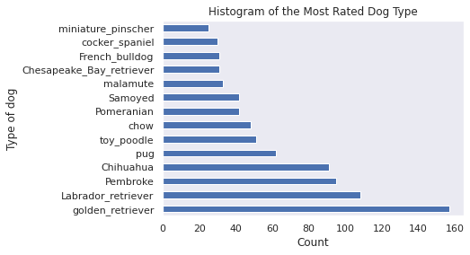

**From the figure above, Golden retriever is the most common dog with a count of 157**

### The Distribution of Dog Stages

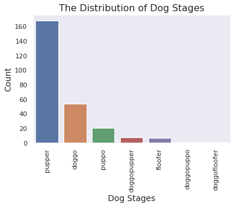

**Pupper is the highly distributed stage of dog in the dataset**

### Total Number of Favorites and Retweets per Dog Stage

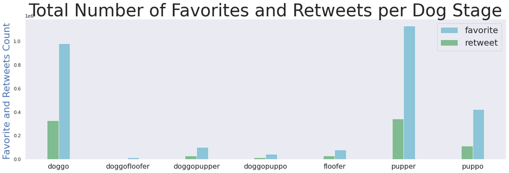

**Pupper is the most retweeted and favorite rating dog in the dataset**